# Capstone Week 4 Quiz

Wenjing Liu

January 23, 2019

## Quiz 3: Natural language processing II

Data Science Capstone: https://www.coursera.org/learn/data-science-project/  
Quiz: https://www.coursera.org/learn/data-science-project/exam/QbBvW/quiz-2-natural-language-processing-i  
Refer to this report for statistics: http://www.modsimworld.org/papers/2015/Natural_Language_Processing.pdf

```r
library(stringr)
library(tm)
library(ggplot2)
library(ngram)

## constants
# original texts
co_twitter_en = "../data/capstone/en_US/en_US.twitter.txt"
co_blogs_en = "../data/capstone/en_US/en_US.blogs.txt"
co_news_en = "../data/capstone/en_US/en_US.news.txt"
# cleaned texts
co_tidy_twitter_en = "../data/capstone/tidy_twitter_en.rds"
co_tidy_blogs_en = "../data/capstone/tidy_blogs_en.rds"
co_tidy_news_en = "../data/capstone/tidy_news_en.rds"
# n-grams
co_3gram_en = "../data/capstone/3gram_en.rds"
co_3gram_notail_en = "../data/capstone/3gram_notail_en.rds"
```

```r
tidyText <- function(file, tidyfile) {

  # read in text
  con <- file(file, open="r")
  lines <- readLines(con)
  close(con)

  lines <- tolower(lines)

  # replace words that contain "@", "#", "http://", "https://"
  # with space (especially for Twitter text)
  lines <- gsub("([^[:space:]]*)(@|#|http://|https://)([^[:space:]]*)", " ", lines)

  # split at all ".", ",", brackets and etc.
  lines <- unlist(strsplit(lines, "[.,:;!?(){}<>]|[][]+"))

  # replace all non-alphanumeric characters with a space at the beginning/end of a word.
  lines <- gsub("^[^a-z0-9]+|[^a-z0-9]+$", " ", lines) # at the begining/end of a line
  lines <- gsub("[^a-z0-9]+\\s", " ", lines) # before space
  lines <- gsub("\\s[^a-z0-9]+", " ", lines) # after space

  # split a string at spaces then remove the words
  # that contain any non-alphabetic characters (excpet "-", "'")
  # then paste them together (separate them with spaces)
  lines <- unlist(lapply(lines, function(line){
    words <- unlist(strsplit(line, "\\s+"))
    words <- words[!grepl("[^a-z'-]", words, perl=TRUE)]
    paste(words, collapse=" ")}))

  # remove axcess spaces
  #lines <- gsub("\\s+", " ", lines) # remove mutiple spaces
  lines <- str_trim(lines) # remove spaces at the beginning/end of the line

  # drop blank lines
  lines <- lines[nchar(lines)>0]

  saveRDS(lines, file=tidyfile)
}

# clean texts
tidyText(co_twitter_en, co_tidy_twitter_en) # 12.52235 mins, 6,658 KB
tidyText(co_news_en, co_tidy_news_en) # 45.31975 secs, 70,998 KB
tidyText(co_blogs_en, co_tidy_blogs_en) # 9.873513 mins, 87,014 KB

# merge texts
df_news <- readRDS(co_tidy_news_en) # 340061 lines
df_blogs <- readRDS(co_tidy_blogs_en) # 4532671 lines
df_twitter <- readRDS(co_tidy_twitter_en) # 5030042 lines
lines <- c(df_news, df_blogs, df_twitter)
rm(df_news, df_blogs, df_twitter)

# get 3-grams
# remove lines that contain less than 3 words, or ngram() would throw errors.
lines <- lines[str_count(lines, "\\s+")>1] # reduced 9902774 lines to 7607099 lines
trigram <- ngram(lines, n=3); rm(lines) # 7.619798 mins
df <- get.phrasetable(trigram); rm(trigram) # 3.286831 mins
saveRDS(df, co_3gram_en) # 211,607 KB
```

```r
df <- readRDS(co_3gram_en) # 22662982 objects
```

The 3-gram dictionary has a long tail.

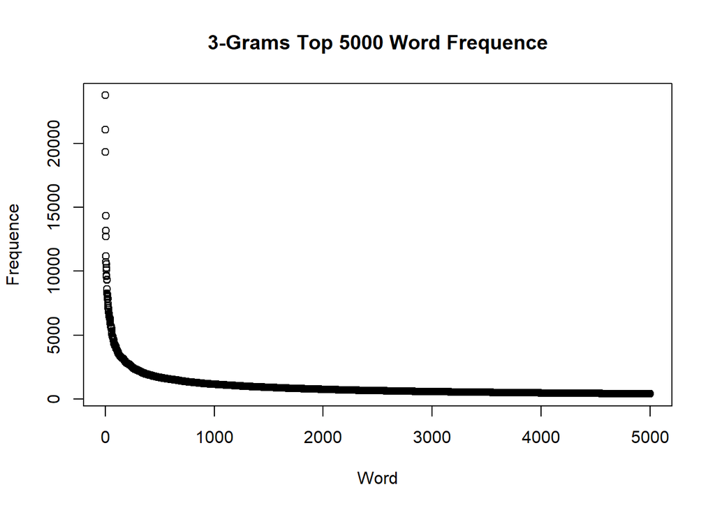

```r
plot(df[1:5000,]$freq,
     main='3-Grams Top 5000 Word Frequence',
     ylab="Frequence",
     xlab="Word")
```

```r
rbind(head(df, 10), tail(df, 10))
```

```
##                                ngrams  freq         prop
## 1                     thanks for the  23773 4.798102e-04
## 2                         one of the  21097 4.258006e-04
## 3                           a lot of  19349 3.905207e-04
## 4                          i want to  14337 2.893635e-04
## 5                            to be a  13162 2.656485e-04
## 6                        going to be  12722 2.567680e-04
## 7                           i have a  11167 2.253835e-04
## 8                          i have to  10713 2.162204e-04
## 9                 looking forward to  10554 2.130113e-04
## 10                          it was a  10284 2.075619e-04
## 22662973            off canceled for      1 2.018299e-08
## 22662974        like immigrant blame      1 2.018299e-08
## 22662975            the six pictures      1 2.018299e-08
## 22662976       neighbors meeting and      1 2.018299e-08
## 22662977              just my honest      1 2.018299e-08
## 22662978                shows on cbs      1 2.018299e-08
## 22662979         patriots laughed at      1 2.018299e-08
## 22662980            yourself a green      1 2.018299e-08
## 22662981               answer to two      1 2.018299e-08
## 22662982 hype from industry-friendly      1 2.018299e-08
```

Remove 3-grams with freqence = 1 (the long tail)

```r
df_notail <- df[df$freq>1,]
saveRDS(df_notail, co_3gram_notail_en) # 32,995 KB
```

```r
df_notail <- readRDS(co_3gram_notail_en)
dim(df_notail)
```

```
## [1] 4060396       3
```

The reduced 3-gram dictionary contains 17.91% original 3-grams, covers 62.45% instances, sizes 15% of the full 3-gram dictionary.

```r
c(nrow(df_notail)/nrow(df),
sum(df_notail$freq)/sum(df$freq),
32995/211607)
```

```
## [1] 0.1791642 0.6245442 0.1559258
```

**For each of the sentence fragments below use your natural language processing algorithm to predict the next word in the sentence.**

### 1. When you breathe, I want to be the air for you. I’ll be there for you, I’d live and I’d

**give (wrong)**  
sleep  
eat  
die (right)

```r
rbind(df[grep("^and i'd give", df[,1]),],
      df[grep("^and i'd sleep", df[,1]),],
      df[grep("^and i'd eat", df[,1]),],
      df[grep("^and i'd die", df[,1]),])
```

```
##                  ngrams freq         prop
## 637961    and i'd give     7 1.412809e-07
## 17385622 and i'd given     1 2.018299e-08
## 11506360   and i'd eat     1 2.018299e-08
```

```r
rbind(df_notail[grep("^and i'd give", df_notail[,1]),],
      df_notail[grep("^and i'd sleep", df_notail[,1]),],
      df_notail[grep("^and i'd eat", df_notail[,1]),],
      df_notail[grep("^and i'd die", df_notail[,1]),])
```

```
##               ngrams freq         prop
## 637961 and i'd give     7 1.412809e-07
```

### 2. Guy at my table’s wife got up to go to the bathroom and I asked about dessert and he started telling me about his

horticultural  
**spiritual (wrong)**  
marital (right)  
financial

```r
rbind(df[grep("^about his horticultural", df[,1]),],
      df[grep("^about his spiritual", df[,1]),],
      df[grep("^about his marital", df[,1]),],
      df[grep("^about his financial", df[,1]),])
```

```
##                        ngrams freq         prop
## 14865805 about his spiritual     1 2.018299e-08
```

```r
rbind(df_notail[grep("^about his horticultural", df_notail[,1]),],
      df_notail[grep("^about his spiritual", df_notail[,1]),],
      df_notail[grep("^about his marital", df_notail[,1]),],
      df_notail[grep("^about his financial", df_notail[,1]),])
```

```
## [1] ngrams freq   prop
## <0 rows> (or 0-length row.names)
```

### 3. I’d give anything to see arctic monkeys this

**weekend**  
month  
decade  
morning

```r
head(df[grep("^monkeys this", df[,1]),], 10)
```

```
## [1] ngrams freq   prop
## <0 rows> (or 0-length row.names)
```

```r
head(df[grep("^arctic monkeys", df[,1]),], 10)
```

```
##                           ngrams freq         prop
## 2229165     arctic monkeys with     2 4.036598e-08
## 3266611      arctic monkeys and     2 4.036598e-08
## 5066428  arctic monkeys opening     1 2.018299e-08
## 6107215     arctic monkeys last     1 2.018299e-08
## 6456208    arctic monkeys opens     1 2.018299e-08
## 6754268  arctic monkeys tonight     1 2.018299e-08
## 7919258       arctic monkeys my     1 2.018299e-08
## 8915715   arctic monkeys humbug     1 2.018299e-08
## 9984819  arctic monkeys classic     1 2.018299e-08
## 12425907     arctic monkeys idk     1 2.018299e-08
```

```r
rbind(head(df[grep("this weekend", df[,1]),], 1),
      head(df[grep("this month", df[,1]),], 1),
      head(df[grep("this decade", df[,1]),], 1),
      head(df[grep("this morning", df[,1]),], 1))
```

```
##                     ngrams freq         prop
## 6276     for this weekend   336 6.781485e-06
## 12333  earlier this month   205 4.137513e-06
## 511919     of this decade     9 1.816469e-07
## 3123     this morning and   554 1.118138e-05
```

```r
rbind(head(df_notail[grep("this weekend", df_notail[,1]),], 1),
      head(df_notail[grep("this month", df_notail[,1]),], 1),
      head(df_notail[grep("this decade", df_notail[,1]),], 1),
      head(df_notail[grep("this morning", df_notail[,1]),], 1))
```

```
##                     ngrams freq         prop
## 6276     for this weekend   336 6.781485e-06
## 12333  earlier this month   205 4.137513e-06
## 511919     of this decade     9 1.816469e-07
## 3123     this morning and   554 1.118138e-05
```

### 4. Talking to your mom has the same effect as a hug and helps reduce your

hunger  
**stress**  
happiness  
sleepiness

```r
head(df[grep("^reduce your", df[,1]),], 5)
```

```
##                        ngrams freq         prop
## 274618      reduce your risk    15 3.027449e-07
## 1100192   reduce your stress     4 8.073196e-08
## 1376907    reduce your costs     4 8.073196e-08
## 1523574     reduce your debt     3 6.054897e-08
## 1561405 reduce your exposure     3 6.054897e-08
```

```r
rbind(head(df[grep("^reduce your hunger", df[,1]),], 1),
      head(df[grep("^reduce your stress", df[,1]),], 1),
      head(df[grep("^reduce your happiness", df[,1]),], 1),
      head(df[grep("^reduce your sleepiness", df[,1]),], 1))
```

```
##                      ngrams freq         prop
## 1100192 reduce your stress     4 8.073196e-08
```

```r
rbind(head(df_notail[grep("^reduce your hunger", df_notail[,1]),], 1),
      head(df_notail[grep("^reduce your stress", df_notail[,1]),], 1),
      head(df_notail[grep("^reduce your happiness", df_notail[,1]),], 1),
      head(df_notail[grep("^reduce your sleepiness", df_notail[,1]),], 1))
```

```
##                      ngrams freq         prop
## 1100192 reduce your stress     4 8.073196e-08
```

### 5. When you were in Holland you were like 1 inch away from me but you hadn’t time to take a

**look (wrong)**  
picture (right)  
walk  
minute

```r
head(df[grep("^take a ", df[,1]),], 5)
```

```
##               ngrams freq         prop
## 879     take a look  1227 2.476453e-05
## 3893 take a picture   474 9.566738e-06
## 4172     take a nap   450 9.082346e-06
## 5001   take a break   395 7.972281e-06
## 6254  take a moment   337 6.801668e-06
```

```r
head(df_notail[grep("^take a ", df_notail[,1]),], 5)
```

```
##               ngrams freq         prop
## 879     take a look  1227 2.476453e-05
## 3893 take a picture   474 9.566738e-06
## 4172     take a nap   450 9.082346e-06
## 5001   take a break   395 7.972281e-06
## 6254  take a moment   337 6.801668e-06
```

### 6. I’d just like all of these questions answered, a presentation of evidence, and a jury to settle the

incident  
account  
matter (right)  
**case (wrong)**

```r
head(df[grep("^settle the ", df[,1]),], 5)
```

```
##                     ngrams freq         prop
## 908372    settle the bill     5 1.009150e-07
## 910045   settle the score     5 1.009150e-07
## 943200    settle the case     5 1.009150e-07
## 1282749 settle the matter     4 8.073196e-08
## 1326203  settle the issue     4 8.073196e-08
```

```r
head(df_notail[grep("^settle the ", df_notail[,1]),], 5)
```

```
##                     ngrams freq         prop
## 908372    settle the bill     5 1.009150e-07
## 910045   settle the score     5 1.009150e-07
## 943200    settle the case     5 1.009150e-07
## 1282749 settle the matter     4 8.073196e-08
## 1326203  settle the issue     4 8.073196e-08
```

### 7. I can’t deal with unsymetrical things. I can’t even hold an uneven number of bags of groceries in each

finger  
arm  
toe  
**hand**

```r
rbind(head(df[grep("^in each finger", df[,1]),], 1),
      head(df[grep("^in each arm", df[,1]),], 1),
      head(df[grep("^in each toe", df[,1]),], 1),
      head(df[grep("^in each hand", df[,1]),], 1))
```

```
##                ngrams freq         prop
## 1237294 in each arms     4 8.073196e-08
## 231077  in each hand    18 3.632938e-07
```

```r
rbind(head(df_notail[grep("^in each finger", df_notail[,1]),], 1),
      head(df_notail[grep("^in each arm", df_notail[,1]),], 1),
      head(df_notail[grep("^in each toe", df_notail[,1]),], 1),
      head(df_notail[grep("^in each hand", df_notail[,1]),], 1))
```

```
##                ngrams freq         prop
## 1237294 in each arms     4 8.073196e-08
## 231077  in each hand    18 3.632938e-07
```

### 8. Every inch of you is perfect from the bottom to the

side  
center  
**top**  
middle

```r
rbind(head(df[grep("^to the side", df[,1]),], 1),
      head(df[grep("^to the center", df[,1]),], 1),
      head(df[grep("^to the top", df[,1]),], 1),
      head(df[grep("^to the middle", df[,1]),], 1))
```

```
##               ngrams freq         prop
## 5463    to the side   370 7.467707e-06
## 19215 to the center   146 2.946717e-06
## 1396     to the top   944 1.905274e-05
## 20898 to the middle   137 2.765070e-06
```

```r
rbind(head(df_notail[grep("^to the side", df_notail[,1]),], 1),
      head(df_notail[grep("^to the center", df_notail[,1]),], 1),
      head(df_notail[grep("^to the top", df_notail[,1]),], 1),
      head(df_notail[grep("^to the middle", df_notail[,1]),], 1))
```

```
##               ngrams freq         prop
## 5463    to the side   370 7.467707e-06
## 19215 to the center   146 2.946717e-06
## 1396     to the top   944 1.905274e-05
## 20898 to the middle   137 2.765070e-06
```

### 9. I’m thankful my childhood was filled with imagination and bruises from playing

inside  
daily  
weekly  
**outside**

```r
head(df[grep("^from playing", df[,1]),], 10)
```

```
##                           ngrams freq         prop
## 288872         from playing the    15 3.027449e-07
## 657602        from playing with     7 1.412809e-07
## 1059558 from playing basketball     5 1.009150e-07
## 1539602         from playing at     3 6.054897e-08
## 1545579         from playing so     3 6.054897e-08
## 1814394    from playing outside     3 6.054897e-08
## 1908553         from playing in     3 6.054897e-08
## 1947543         from playing on     3 6.054897e-08
## 2013344          from playing a     3 6.054897e-08
## 2406696         from playing my     2 4.036598e-08
```

```r
head(df_notail[grep("^from playing", df_notail[,1]),], 10)
```

```
##                           ngrams freq         prop
## 288872         from playing the    15 3.027449e-07
## 657602        from playing with     7 1.412809e-07
## 1059558 from playing basketball     5 1.009150e-07
## 1539602         from playing at     3 6.054897e-08
## 1545579         from playing so     3 6.054897e-08
## 1814394    from playing outside     3 6.054897e-08
## 1908553         from playing in     3 6.054897e-08
## 1947543         from playing on     3 6.054897e-08
## 2013344          from playing a     3 6.054897e-08
## 2406696         from playing my     2 4.036598e-08
```

### 10. I like how the same people are in almost all of Adam Sandler’s

stories  
**movies**  
pictures  
novels

```r
head(df[grep("^adam sandler's ", df[,1]),], 5)
```

```
##                             ngrams freq         prop
## 10343550   adam sandler's grandma     1 2.018299e-08
## 11814967  adam sandler's thoughts     1 2.018299e-08
## 11854765      adam sandler's jack     1 2.018299e-08
## 15764079    adam sandler's recent     1 2.018299e-08
## 17803430 adam sandler's lunchlady     1 2.018299e-08
```

```r
df[grep("adam sandler's", df[,1]),]
```

```
##                             ngrams freq         prop
## 5354146        was adam sandler's     1 2.018299e-08
## 10343550   adam sandler's grandma     1 2.018299e-08
## 11463702  watching adam sandler's     1 2.018299e-08
## 11814967  adam sandler's thoughts     1 2.018299e-08
## 11854765      adam sandler's jack     1 2.018299e-08
## 15764079    adam sandler's recent     1 2.018299e-08
## 15770108        at adam sandler's     1 2.018299e-08
## 17803430 adam sandler's lunchlady     1 2.018299e-08
## 21905373     loved adam sandler's     1 2.018299e-08
```